# (Fordgobike)

## Preliminary Wrangling

> This data set includes information about individual rides made in a bike-sharing system for month of February of 2019

```python
# import all packages and set plots to be embedded inline
import numpy as np
import pandas as pd
import matplotlib.pyplot as plt
import seaborn as sb

%matplotlib inline
```

```python
df = pd.read_csv('201902-fordgobike-tripdata.csv')
df.head()
```

|  | duration_sec | start_time | end_time | start_station_id | start_station_name | start_station_latitude | start_station_longitude | end_station_id | end_station_name | end_station_latitude | end_station_longitude | bike_id | user_type | member_birth_year | member_gender | bike_share_for_all_trip |
| --- | --- | --- | --- | --- | --- | --- | --- | --- | --- | --- | --- | --- | --- | --- | --- | --- |
| 0 | 52185 | 2019-02-28 17:32:10.1450 | 2019-03-01 08:01:55.9750 | 21.0 | Montgomery St BART Station (Market St at 2nd St) | 37.789625 | -122.400811 | 13.0 | Commercial St at Montgomery St | 37.794231 | -122.402923 | 4902 | Customer | 1984.0 | Male | No |
| 1 | 42521 | 2019-02-28 18:53:21.7890 | 2019-03-01 06:42:03.0560 | 23.0 | The Embarcadero at Steuart St | 37.791464 | -122.391034 | 81.0 | Berry St at 4th St | 37.775880 | -122.393170 | 2535 | Customer | NaN | NaN | No |
| 2 | 61854 | 2019-02-28 12:13:13.2180 | 2019-03-01 05:24:08.1460 | 86.0 | Market St at Dolores St | 37.769305 | -122.426826 | 3.0 | Powell St BART Station (Market St at 4th St) | 37.786375 | -122.404904 | 5905 | Customer | 1972.0 | Male | No |
| 3 | 36490 | 2019-02-28 17:54:26.0100 | 2019-03-01 04:02:36.8420 | 375.0 | Grove St at Masonic Ave | 37.774836 | -122.446546 | 70.0 | Central Ave at Fell St | 37.773311 | -122.444293 | 6638 | Subscriber | 1989.0 | Other | No |
| 4 | 1585 | 2019-02-28 23:54:18.5490 | 2019-03-01 00:20:44.0740 | 7.0 | Frank H Ogawa Plaza | 37.804562 | -122.271738 | 222.0 | 10th Ave at E 15th St | 37.792714 | -122.248780 | 4898 | Subscriber | 1974.0 | Male | Yes |

```python
df.shape
```

```
(183412, 16)
```

```python
df.describe()
```

|  | duration_sec | start_station_id | start_station_latitude | start_station_longitude | end_station_id | end_station_latitude | end_station_longitude | bike_id | member_birth_year |
| --- | --- | --- | --- | --- | --- | --- | --- | --- | --- |
| count | 183412.000000 | 183215.000000 | 183412.000000 | 183412.000000 | 183215.000000 | 183412.000000 | 183412.000000 | 183412.000000 | 175147.000000 |
| mean | 726.078435 | 138.590427 | 37.771223 | -122.352664 | 136.249123 | 37.771427 | -122.352250 | 4472.906375 | 1984.806437 |
| std | 1794.389780 | 111.778864 | 0.099581 | 0.117097 | 111.515131 | 0.099490 | 0.116673 | 1664.383394 | 10.116689 |
| min | 61.000000 | 3.000000 | 37.317298 | -122.453704 | 3.000000 | 37.317298 | -122.453704 | 11.000000 | 1878.000000 |
| 25% | 325.000000 | 47.000000 | 37.770083 | -122.412408 | 44.000000 | 37.770407 | -122.411726 | 3777.000000 | 1980.000000 |
| 50% | 514.000000 | 104.000000 | 37.780760 | -122.398285 | 100.000000 | 37.781010 | -122.398279 | 4958.000000 | 1987.000000 |
| 75% | 796.000000 | 239.000000 | 37.797280 | -122.286533 | 235.000000 | 37.797320 | -122.288045 | 5502.000000 | 1992.000000 |
| max | 85444.000000 | 398.000000 | 37.880222 | -121.874119 | 398.000000 | 37.880222 | -121.874119 | 6645.000000 | 2001.000000 |

```python
df.info()
```

```
<class 'pandas.core.frame.DataFrame'>
RangeIndex: 183412 entries, 0 to 183411
Data columns (total 16 columns):
 #   Column                   Non-Null Count   Dtype
---  ------                   --------------   -----
 0   duration_sec             183412 non-null  int64
 1   start_time               183412 non-null  object
 2   end_time                 183412 non-null  object
 3   start_station_id         183215 non-null  float64
 4   start_station_name       183215 non-null  object
 5   start_station_latitude   183412 non-null  float64
 6   start_station_longitude  183412 non-null  float64
 7   end_station_id           183215 non-null  float64
 8   end_station_name         183215 non-null  object
 9   end_station_latitude     183412 non-null  float64
 10  end_station_longitude    183412 non-null  float64
 11  bike_id                  183412 non-null  int64
 12  user_type                183412 non-null  object
 13  member_birth_year        175147 non-null  float64
 14  member_gender            175147 non-null  object
 15  bike_share_for_all_trip  183412 non-null  object
dtypes: float64(7), int64(2), object(7)
memory usage: 22.4+ MB
```

#### look at duplicated rows

```python
df.duplicated().any()
```

```
False
```

#### is there any null values?

```python
df.isna().sum()
```

```
duration_sec                  0
start_time                    0
end_time                      0
start_station_id            197
start_station_name          197
start_station_latitude        0
start_station_longitude       0
end_station_id              197
end_station_name            197
end_station_latitude          0
end_station_longitude         0
bike_id                       0
user_type                     0
member_birth_year          8265
member_gender              8265
bike_share_for_all_trip       0
dtype: int64
```

##### drop nulls

```python
df.dropna(inplace=True)
```

##### check

```python
df.isna().sum()
```

```
duration_sec               0
start_time                 0
end_time                   0
start_station_id           0
start_station_name         0
start_station_latitude     0
start_station_longitude    0
end_station_id             0
end_station_name           0
end_station_latitude       0
end_station_longitude      0
bike_id                    0
user_type                  0
member_birth_year          0
member_gender              0
bike_share_for_all_trip    0
dtype: int64
```

```python
df.shape
```

```
(174952, 16)
```

#### a brief look at some columns

```python
df.columns
```

```
Index(['duration_sec', 'start_time', 'end_time', 'start_station_id',
       'start_station_name', 'start_station_latitude',
       'start_station_longitude', 'end_station_id', 'end_station_name',
       'end_station_latitude', 'end_station_longitude', 'bike_id', 'user_type',
       'member_birth_year', 'member_gender', 'bike_share_for_all_trip'],
      dtype='object')
```

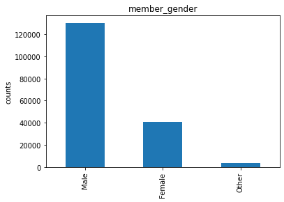

```python
df['member_gender'].value_counts().plot(kind='bar')
plt.title('member_gender')
plt.ylabel('counts')
```

```python
df['user_type'].value_counts()
```

```
Subscriber    158386
Customer       16566
Name: user_type, dtype: int64
```

```python
df['start_station_name'].value_counts()
```

```
Market St at 10th St                                         3649
San Francisco Caltrain Station 2  (Townsend St at 4th St)    3408
Berry St at 4th St                                           2952
Montgomery St BART Station (Market St at 2nd St)             2711
Powell St BART Station (Market St at 4th St)                 2620
                                                             ...
Willow St at Vine St                                            9
Parker Ave at McAllister St                                     7
21st Ave at International Blvd                                  4
Palm St at Willow St                                            3
16th St Depot                                                   2
Name: start_station_name, Length: 329, dtype: int64
```

```python
df['end_station_name'].value_counts()
```

```
San Francisco Caltrain Station 2  (Townsend St at 4th St)    4624
Market St at 10th St                                         3709
Montgomery St BART Station (Market St at 2nd St)             3461
San Francisco Ferry Building (Harry Bridges Plaza)           3151
San Francisco Caltrain (Townsend St at 4th St)               2870
                                                             ...
Parker Ave at McAllister St                                     9
Palm St at Willow St                                            7
16th St Depot                                                   6
21st Ave at International Blvd                                  5
Willow St at Vine St                                            5
Name: end_station_name, Length: 329, dtype: int64
```

```python
df['start_station_id'].value_counts()
```

```
58.0     3649
67.0     3408
81.0     2952
21.0     2711
3.0      2620
         ...
234.0       9
51.0        7
224.0       4
300.0       3
344.0       2
Name: start_station_id, Length: 329, dtype: int64
```

```python
df['bike_id'].value_counts()
```

```
4794    179
4814    172
5175    167
4450    166
5145    165
       ...
2194      1
1786      1
2042      1
5067      1
806       1
Name: bike_id, Length: 4607, dtype: int64
```

```python
df['bike_id'].unique()
```

```
array([4902, 5905, 6638, ..., 2861, 3655, 5067], dtype=int64)
```

```python
df['member_birth_year'].mean()
```

```
1984.8031345740546
```

```python
df['member_birth_year'].value_counts()
```

```
1988.0    10214
1993.0     9323
1989.0     8967
1990.0     8640
1991.0     8484
          ...
1930.0        1
1910.0        1
1927.0        1
1928.0        1
1878.0        1
Name: member_birth_year, Length: 75, dtype: int64
```

##### Add user age column

```python
df['age'] = 2020 - df['member_birth_year'].astype('int')
```

```python
df['age'].value_counts()
```

```
32     10214
27      9323
31      8967
30      8640
29      8484
       ...
93         1
92         1
110        1
90         1
142        1
Name: age, Length: 75, dtype: int64
```

##### convert duration from seconds to minute and add duration(min) column

```python
df['duration_min'] = df['duration_sec'] / 60
```

```python
df['duration_min'].value_counts()
```

```
4.533333      308
5.383333      285
5.083333      282
6.150000      280
5.100000      276
             ...
139.916667      1
127.150000      1
168.466667      1
139.083333      1
71.450000       1
Name: duration_min, Length: 4429, dtype: int64
```

```python
df.info()
```

```
<class 'pandas.core.frame.DataFrame'>
Int64Index: 174952 entries, 0 to 183411
Data columns (total 18 columns):
 #   Column                   Non-Null Count   Dtype
---  ------                   --------------   -----
 0   duration_sec             174952 non-null  int64
 1   start_time               174952 non-null  object
 2   end_time                 174952 non-null  object
 3   start_station_id         174952 non-null  float64
 4   start_station_name       174952 non-null  object
 5   start_station_latitude   174952 non-null  float64
 6   start_station_longitude  174952 non-null  float64
 7   end_station_id           174952 non-null  float64
 8   end_station_name         174952 non-null  object
 9   end_station_latitude     174952 non-null  float64
 10  end_station_longitude    174952 non-null  float64
 11  bike_id                  174952 non-null  int64
 12  user_type                174952 non-null  object
 13  member_birth_year        174952 non-null  float64
 14  member_gender            174952 non-null  object
 15  bike_share_for_all_trip  174952 non-null  object
 16  age                      174952 non-null  int32
 17  duration_min             174952 non-null  float64
dtypes: float64(8), int32(1), int64(2), object(7)
memory usage: 24.7+ MB
```

##### extract hours and weekday from start time column

```python
#covert from object to datetime
df['start_time'] = pd.to_datetime(df['start_time'])
df.info()
```

```
<class 'pandas.core.frame.DataFrame'>
Int64Index: 174952 entries, 0 to 183411
Data columns (total 18 columns):
 #   Column                   Non-Null Count   Dtype
---  ------                   --------------   -----
 0   duration_sec             174952 non-null  int64
 1   start_time               174952 non-null  datetime64[ns]
 2   end_time                 174952 non-null  object
 3   start_station_id         174952 non-null  float64
 4   start_station_name       174952 non-null  object
 5   start_station_latitude   174952 non-null  float64
 6   start_station_longitude  174952 non-null  float64
 7   end_station_id           174952 non-null  float64
 8   end_station_name         174952 non-null  object
 9   end_station_latitude     174952 non-null  float64
 10  end_station_longitude    174952 non-null  float64
 11  bike_id                  174952 non-null  int64
 12  user_type                174952 non-null  object
 13  member_birth_year        174952 non-null  float64
 14  member_gender            174952 non-null  object
 15  bike_share_for_all_trip  174952 non-null  object
 16  age                      174952 non-null  int32
 17  duration_min             174952 non-null  float64
dtypes: datetime64[ns](1), float64(8), int32(1), int64(2), object(6)
memory usage: 24.7+ MB
```

```python
#extract hour and days
df['start_time_hour'] = df['start_time'].dt.hour
df['start_time_day'] = df['start_time'].dt.strftime('%a')
```

```python
#check
df.info()
```

```
<class 'pandas.core.frame.DataFrame'>
Int64Index: 174952 entries, 0 to 183411
Data columns (total 20 columns):
 #   Column                   Non-Null Count   Dtype
---  ------                   --------------   -----
 0   duration_sec             174952 non-null  int64
 1   start_time               174952 non-null  datetime64[ns]
 2   end_time                 174952 non-null  object
 3   start_station_id         174952 non-null  float64
 4   start_station_name       174952 non-null  object
 5   start_station_latitude   174952 non-null  float64
 6   start_station_longitude  174952 non-null  float64
 7   end_station_id           174952 non-null  float64
 8   end_station_name         174952 non-null  object
 9   end_station_latitude     174952 non-null  float64
 10  end_station_longitude    174952 non-null  float64
 11  bike_id                  174952 non-null  int64
 12  user_type                174952 non-null  object
 13  member_birth_year        174952 non-null  float64
 14  member_gender            174952 non-null  object
 15  bike_share_for_all_trip  174952 non-null  object
 16  age                      174952 non-null  int32
 17  duration_min             174952 non-null  float64
 18  start_time_hour          174952 non-null  int64
 19  start_time_day           174952 non-null  object
dtypes: datetime64[ns](1), float64(8), int32(1), int64(3), object(7)
memory usage: 27.4+ MB
```

```python
df.head()
```

|  | duration_sec | start_time | end_time | start_station_id | start_station_name | start_station_latitude | start_station_longitude | end_station_id | end_station_name | end_station_latitude | end_station_longitude | bike_id | user_type | member_birth_year | member_gender | bike_share_for_all_trip | age | duration_min | start_time_hour | start_time_day |
| --- | --- | --- | --- | --- | --- | --- | --- | --- | --- | --- | --- | --- | --- | --- | --- | --- | --- | --- | --- | --- |
| 0 | 52185 | 2019-02-28 17:32:10.145 | 2019-03-01 08:01:55.9750 | 21.0 | Montgomery St BART Station (Market St at 2nd St) | 37.789625 | -122.400811 | 13.0 | Commercial St at Montgomery St | 37.794231 | -122.402923 | 4902 | Customer | 1984.0 | Male | No | 36 | 869.750000 | 17 | Thu |
| 2 | 61854 | 2019-02-28 12:13:13.218 | 2019-03-01 05:24:08.1460 | 86.0 | Market St at Dolores St | 37.769305 | -122.426826 | 3.0 | Powell St BART Station (Market St at 4th St) | 37.786375 | -122.404904 | 5905 | Customer | 1972.0 | Male | No | 48 | 1030.900000 | 12 | Thu |
| 3 | 36490 | 2019-02-28 17:54:26.010 | 2019-03-01 04:02:36.8420 | 375.0 | Grove St at Masonic Ave | 37.774836 | -122.446546 | 70.0 | Central Ave at Fell St | 37.773311 | -122.444293 | 6638 | Subscriber | 1989.0 | Other | No | 31 | 608.166667 | 17 | Thu |
| 4 | 1585 | 2019-02-28 23:54:18.549 | 2019-03-01 00:20:44.0740 | 7.0 | Frank H Ogawa Plaza | 37.804562 | -122.271738 | 222.0 | 10th Ave at E 15th St | 37.792714 | -122.248780 | 4898 | Subscriber | 1974.0 | Male | Yes | 46 | 26.416667 | 23 | Thu |
| 5 | 1793 | 2019-02-28 23:49:58.632 | 2019-03-01 00:19:51.7600 | 93.0 | 4th St at Mission Bay Blvd S | 37.770407 | -122.391198 | 323.0 | Broadway at Kearny | 37.798014 | -122.405950 | 5200 | Subscriber | 1959.0 | Male | No | 61 | 29.883333 | 23 | Thu |

##### remove not needed columns

```python
#drop not needed columns
rem_columns = ['duration_sec', 'start_time', 'end_time', 'start_station_id', 'start_station_latitude',
               'start_station_longitude', 'end_station_id', 'end_station_latitude', 'end_station_longitude',
               'member_birth_year', 'bike_share_for_all_trip', ]
df_clean = df.drop(columns=rem_columns)
```

```python
#check
df_clean.shape
```

```
(174952, 9)
```

```python
df_clean.head()
```

|  | start_station_name | end_station_name | bike_id | user_type | member_gender | age | duration_min | start_time_hour | start_time_day |
| --- | --- | --- | --- | --- | --- | --- | --- | --- | --- |
| 0 | Montgomery St BART Station (Market St at 2nd St) | Commercial St at Montgomery St | 4902 | Customer | Male | 36 | 869.750000 | 17 | Thu |
| 2 | Market St at Dolores St | Powell St BART Station (Market St at 4th St) | 5905 | Customer | Male | 48 | 1030.900000 | 12 | Thu |
| 3 | Grove St at Masonic Ave | Central Ave at Fell St | 6638 | Subscriber | Other | 31 | 608.166667 | 17 | Thu |
| 4 | Frank H Ogawa Plaza | 10th Ave at E 15th St | 4898 | Subscriber | Male | 46 | 26.416667 | 23 | Thu |
| 5 | 4th St at Mission Bay Blvd S | Broadway at Kearny | 5200 | Subscriber | Male | 61 | 29.883333 | 23 | Thu |

```python
df_clean.describe()
```

|  | bike_id | age | duration_min | start_time_hour |
| --- | --- | --- | --- | --- |
| count | 174952.000000 | 174952.000000 | 174952.000000 | 174952.000000 |
| mean | 4482.587555 | 35.196865 | 11.733379 | 13.456165 |
| std | 1659.195937 | 10.118731 | 27.370082 | 4.734282 |
| min | 11.000000 | 19.000000 | 1.016667 | 0.000000 |
| 25% | 3799.000000 | 28.000000 | 5.383333 | 9.000000 |
| 50% | 4960.000000 | 33.000000 | 8.500000 | 14.000000 |
| 75% | 5505.000000 | 40.000000 | 13.150000 | 17.000000 |
| max | 6645.000000 | 142.000000 | 1409.133333 | 23.000000 |

```python
df_clean.info()
```

```
<class 'pandas.core.frame.DataFrame'>
Int64Index: 174952 entries, 0 to 183411
Data columns (total 9 columns):
 #   Column              Non-Null Count   Dtype
---  ------              --------------   -----
 0   start_station_name  174952 non-null  object
 1   end_station_name    174952 non-null  object
 2   bike_id             174952 non-null  int64
 3   user_type           174952 non-null  object
 4   member_gender       174952 non-null  object
 5   age                 174952 non-null  int32
 6   duration_min        174952 non-null  float64
 7   start_time_hour     174952 non-null  int64
 8   start_time_day      174952 non-null  object
dtypes: float64(1), int32(1), int64(2), object(5)
memory usage: 12.7+ MB
```

### What is/are the main feature(s) of interest in your dataset?

> User_type, user_gender, duration

### What features in the dataset do you think will help support your investigation into your feature(s) of interest?

> 'start_station_name', 'end_station_name', 'bike_id', 'user_type', 'member_gender', 'duration_min', 'age', 'start_time_hour', 'start_time_day'

## Univariate Exploration

```
(0.0, 100.0)
```

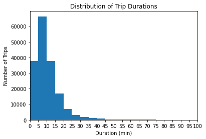

```python
#Distribution of Trip Durations
bins = np.arange(0, df['duration_min'].max()+5, 5)
plt.hist(data = df_clean, x = 'duration_min', bins = bins)
plt.title('Distribution of Trip Durations')
plt.xlabel('Duration (min)')
plt.ylabel('Number of Trips')
plt.xticks(np.arange(0, df['duration_min'].max()+5, 5))
plt.xlim(0,100)
```

> Most of the time people used the bike was from five to ten minutes

[output not shown]

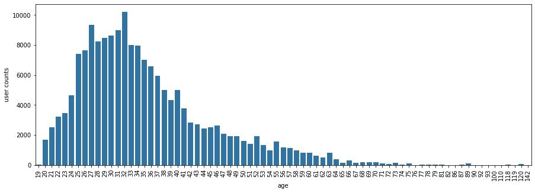

```python
#visual ages
base_color = sb.color_palette()[0]
plt.figure(figsize=[15,5])
sb.countplot(data=df_clean, x='age', color=base_color)
plt.xlabel('age')
plt.ylabel('user counts')
plt.xticks(rotation=90)
```

```python
#clean age more than 80
df_clean = df_clean[df_clean['age'] <= 80]
```

[output not shown]

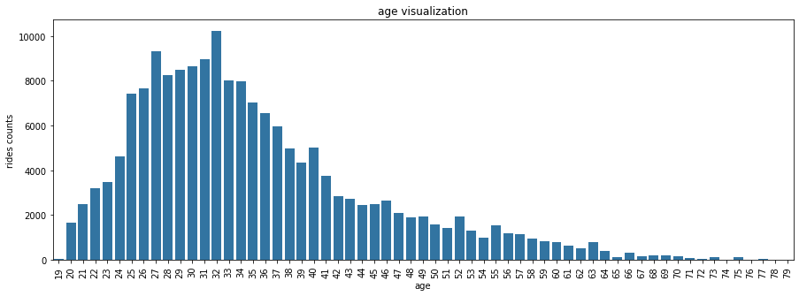

```python
#visual age less than 80
plt.figure(figsize=[15,5])
sb.countplot(data=df_clean, x='age', color=base_color)
plt.title('age visualization')
plt.xlabel('age')
plt.ylabel('rides counts')
plt.xticks(rotation=90)
```

> right skewed is very normal but there are unexpected ages ( 100,120,142...etc), so i worked with ages record less than 80 years old

> > 32 is the most age use the bikes

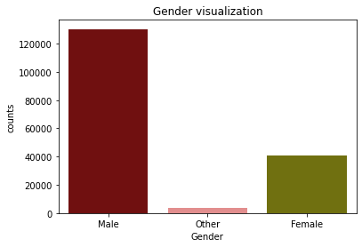

```python
# Gender visualization
colors = ['maroon', 'lightcoral', 'olive']
sb.countplot(data=df_clean, x='member_gender', palette=colors)
plt.title('Gender visualization')
plt.xlabel('Gender')
plt.ylabel('counts')
```

> There is a big difference between male and female users

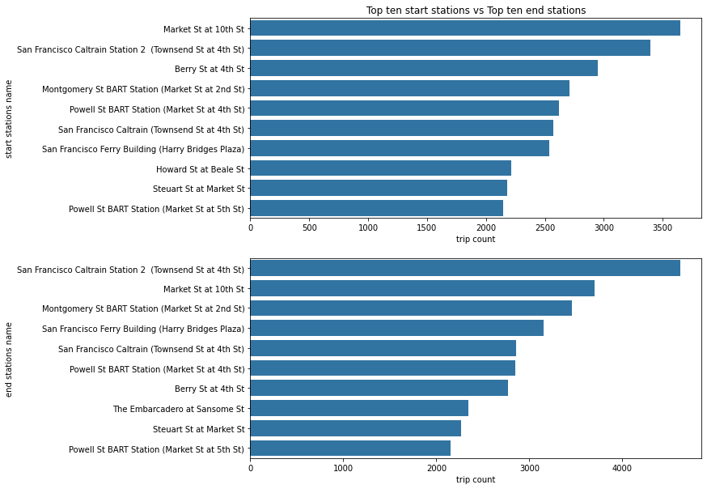

```python
# Explore Top ten start stations vs Top ten end stations
plt.figure(figsize = [10,10])
plt.subplot(2,1,1)
start_order = df_clean['start_station_name'].value_counts()[:10]
df_start = df_clean.loc[df_clean['start_station_name'].isin(start_order.index)]
sb.countplot(data = df_start, y = 'start_station_name', order = start_order.index, color = base_color)
plt.title('Top ten start stations vs Top ten end stations')
plt.xlabel('trip count')
plt.ylabel('start stations name')

#top ten end station
plt.subplot(2,1,2)
end_order = df_clean['end_station_name'].value_counts()[:10]
df_end = df_clean.loc[df_clean['end_station_name'].isin(end_order.index)]
sb.countplot(data = df_end, y = 'end_station_name', order = end_order.index, color = base_color);
plt.xlabel('trip count')
plt.ylabel('end stations name')
```

> (Market st, San Francisco caltrain station2, Berry St) are the highest-used stations.

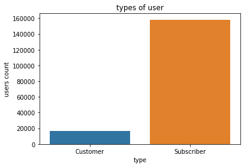

```python
#types of user
sb.countplot(data=df_clean, x='user_type')
plt.title('types of user')
plt.xlabel('type')
plt.ylabel('users count')
```

> most users are subscribers

[output not shown]

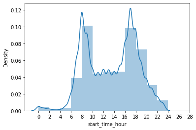

```python
# explore distribution of start times
binsize = np.arange(0,df_clean['start_time_hour'].max()+2,2)
sb.distplot(df_clean['start_time_hour'], bins = binsize)
plt.xticks(np.arange(0,30,2))
```

> 8am to 10am and 4pm to 6pm Most of the times people use the service

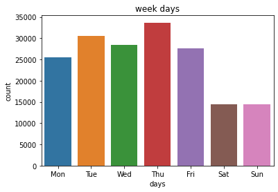

```python
# explore distribution of weekdays
days = ['Mon','Tue','Wed','Thu','Fri','Sat','Sun']
sb.countplot(data=df_clean, x='start_time_day', order = days)
plt.title('week days')
plt.xlabel('days')
```

> sunday and saturday weekends are fewer days for bicycle use

```python
df_clean['start_time_day'].value_counts()
```

```
Thu    33689
Tue    30558
Wed    28396
Fri    27619
Mon    25588
Sun    14492
Sat    14407
Name: start_time_day, dtype: int64
```

### Discuss the distribution(s) of your variable(s) of interest. Were there any unusual points? Did you need to perform any transformations?

> There are unusual records in age column may be human error, so i work with ages less than 80

### Of the features you investigated, were there any unusual distributions? Did you perform any operations on the data to tidy, adjust, or change the form of the data? If so, why did you do this?

> Distributions was very logical, but i did some operations -> add age, start_time_day, and start_time_hour columns ->remove null values ..

## Bivariate Exploration

```python
# convert user_type, and member_gender into ordered categorical types
ordinal_var_dict = {'user_type': ['Subscriber','Customer'],
                    'member_gender': ['Male', 'Female', 'Other']}

for var in ordinal_var_dict:
    pd_ver = pd.__version__.split(".")
    if (int(pd_ver[0]) > 0) or (int(pd_ver[1]) >= 21):
        ordered_var = pd.api.types.CategoricalDtype(ordered = True,
                                                    categories = ordinal_var_dict[var])
        df_clean[var] = df_clean[var].astype(ordered_var)
    else: #
        df_clean[var] = df_clean[var].astype('category', ordered = True,
                                             categories = ordinal_var_dict[var])
```

#### what is the relation between age and gender?

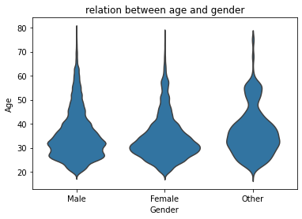

```python
sb.violinplot(data=df_clean, x='member_gender', y='age', inner=None, color=base_color)
plt.title('relation between age and gender')
plt.xlabel('Gender')
plt.ylabel('Age')
```

> male with ages greater than 40 rides more than Female

#### what is the relation between age and duration_min?

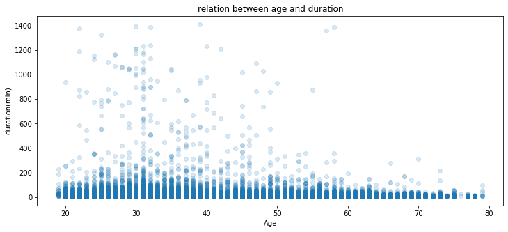

```python
plt.figure(figsize = [12,5])
plt.scatter(x = df_clean['age'], y = df_clean['duration_min'], alpha = 1/6)
plt.title('relation between age and duration')
plt.xlabel('Age')
plt.ylabel('duration(min)')
```

```python
df_clean['duration_min'].corr(df_clean['age'])
```

```
0.007217398910113903
```

#### relation between Gender and Type

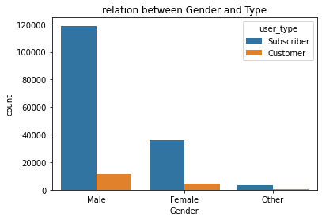

```python
#relation between Gender and Type
sb.countplot(data = df_clean, x = 'member_gender', hue = 'user_type')
plt.title('relation between Gender and Type')
plt.xlabel('Gender')
```

### is there any relation between hours and user type ?!

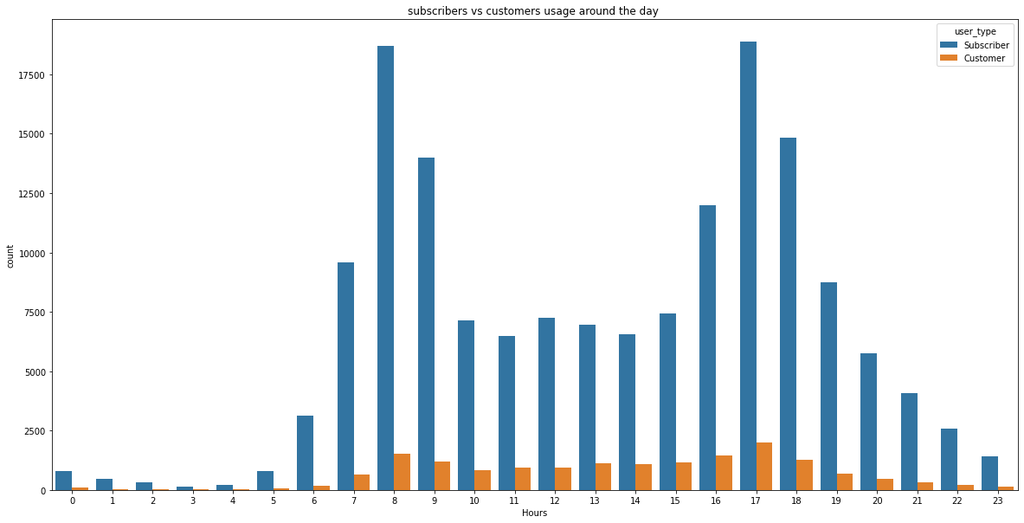

```python
plt.figure(figsize = [20,10])
sb.countplot(data=df_clean, x='start_time_hour', hue='user_type')
plt.title('subscribers vs customers usage around the day ')
plt.xlabel('Hours')
```

> The times when subscribers are used the most are the times of entry and exit of employees

#### relation between days and user type

[output not shown]

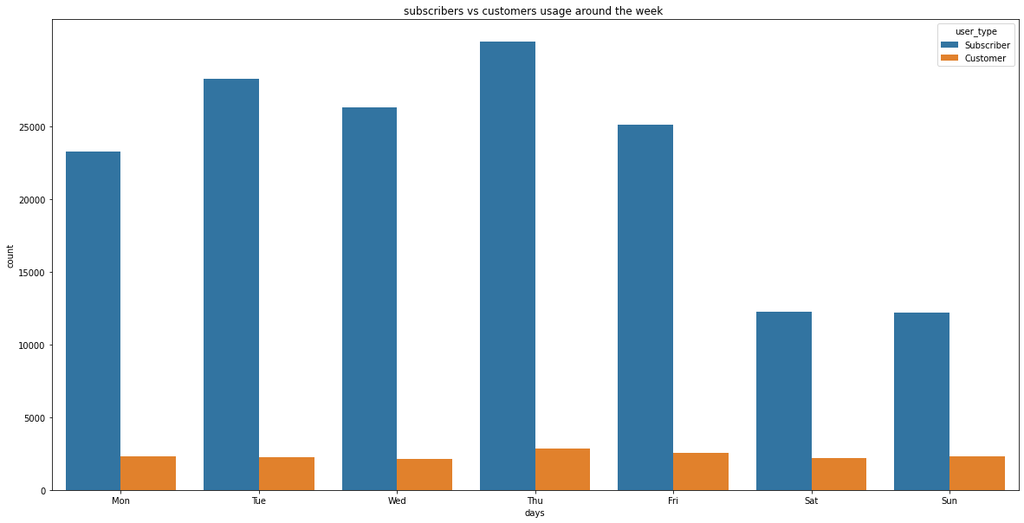

```python
#relation between dayes and user type
plt.figure(figsize = [20,10])
days = ['Mon','Tue','Wed','Thu','Fri','Sat','Sun']
sb.countplot(data=df_clean, x='start_time_day', hue='user_type', order=days)
plt.title('subscribers vs customers usage around the week ')
plt.xlabel('days')
plt.yticks(np.arange(0,30000,5000))
```

> To a large extent, we made sure that the employees are the ones who use this service the most

### Talk about some of the relationships you observed in this part of the investigation. How did the feature(s) of interest vary with other features in the dataset?

> male with ages greater than 40 rides more than Female  
> The times when subscribers are used the most are the times of entry and exit of employees

### Did you observe any interesting relationships between the other features (not the main feature(s) of interest)?

> type and weekdays, type and start hours prove that the employees are the ones who use this service the most

## Multivariate Exploration

> Create plots of three or more variables to investigate your data even further. Make sure that your investigations are justified, and follow from your work in the previous sections.

### is there any relation customer type and gender vs. weekdays?

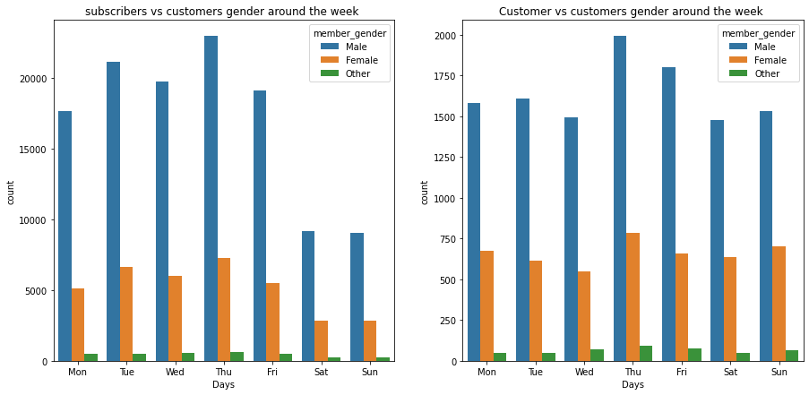

```python
plt.figure(figsize=[15,7])
plt.subplot(1,2,1)
d_s = df_clean[df_clean['user_type']=='Subscriber']
sb.countplot(data=d_s, x='start_time_day', hue='member_gender',order=days)
plt.title('subscribers vs customers gender around the week ')
plt.xlabel('Days')

plt.subplot(1,2,2)
d_c = df_clean[df_clean['user_type']=='Customer']
sb.countplot(data=d_c, x='start_time_day', hue='member_gender',order=days)
plt.title('Customer vs customers gender around the week ')
plt.xlabel('Days')
```

> Female customers have a fixed rate throughout the we ek, but rate of Female subscribers decreases significantly in weekends

> The percentage of women customers in relation to men is relatively higher than the percentage of women subscribers in the ratio of men

> men and women have the same behavior

### expolre customer type and gender vs. start hours

[figure not shown]

```python
#customer type and gender vs. start hours
plt.figure(figsize=[15,7])
plt.subplot(1,2,1)
d_s = df_clean[df_clean['user_type']=='Subscriber']
sb.countplot(data=d_s, x='start_time_hour', hue='member_gender')
plt.title('Customer vs customers gender around the day ')
plt.xlabel('Hour')

plt.subplot(1,2,2)
d_c = df_clean[df_clean['user_type']=='Customer']
sb.countplot(data=d_c, x='start_time_hour', hue='member_gender')
plt.title('Customer vs customers gender around the day ')
plt.xlabel('Hour')
```

> men and women have the same behavior

#### Finding out how the trip time is affected by gender and starthours.

[output not shown]

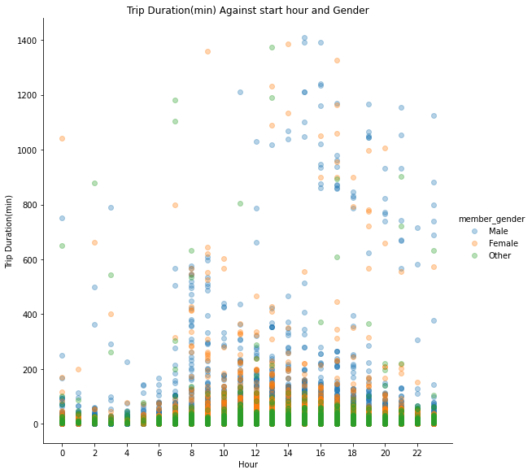

```python
g = sb.FacetGrid(data =  df_clean, hue = 'member_gender', height = 8)
g.map(plt.scatter, 'start_time_hour','duration_min', alpha = 1/3)
g.add_legend()
plt.title('Trip Duration(min) Against start hour and Gender')
plt.xlabel('Hour')
plt.ylabel('Trip Duration(min)')
plt.xticks(np.arange(0,24,2))
```

### Finding out how the average trip time is affected by user type and starthours

[output not shown]

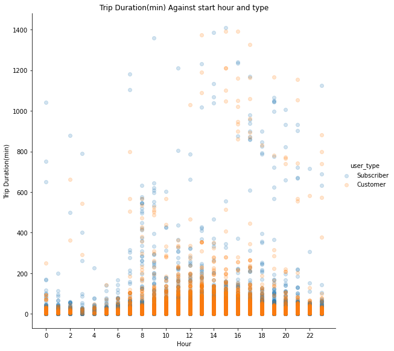

```python
#trip time is affected by user type and starthours?
g = sb.FacetGrid(data =  df_clean, hue = 'user_type', height = 8)
g.map(plt.scatter, 'start_time_hour','duration_min', alpha = 1/5)
g.add_legend()
plt.title('Trip Duration(min) Against start hour and type')
plt.xlabel('Hour')
plt.ylabel('Trip Duration(min)')
plt.xticks(np.arange(0,24,2))
```

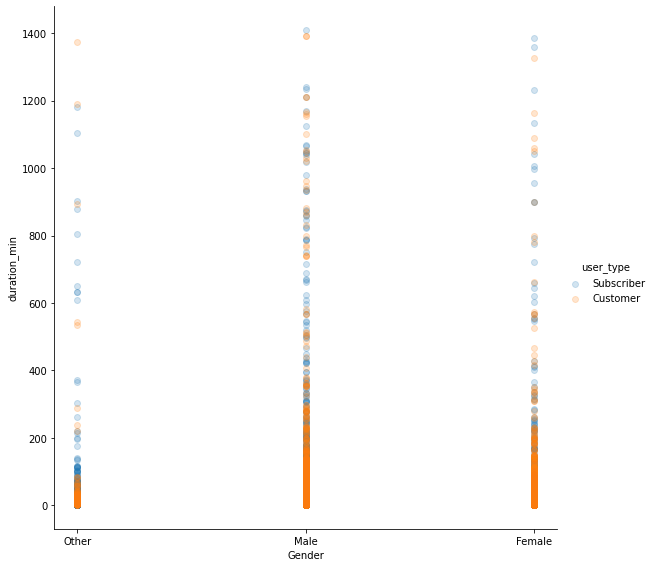

```python
# between type ,gender and  duration
g = sb.FacetGrid(data =  df_clean, hue = 'user_type', height = 8)
g.map(plt.scatter, 'member_gender','duration_min', alpha = 1/5)
g.add_legend()
plt.xlabel('Gender')
```